# Revealing Subreddits' Trending Topics

Data Mining and Wrangling

## Executive Summary

The goal of this notebook is to determine the relevant themes in the collection of titles of the reddit-dmw-sample.txt dataset. The data was cleaned to extract alphanumeric english words only. Afterwards, the dataset was vectorized to determine the frequency of occurrence of a certain set of words in the entire corpus and penalizes the most frequently occurring terms. Kmeans clustering was used to determine the number of clusters. Using internal validation, four clusters was revealed with a super cluster, til cluster, containing more than 90% of the total clusters and the remaining cluster were trump, clinton and sanders.

## 1. Data Description

Data used in this notebook came from Reddit, specifically from the reddit-dmw-sample.txt dataset provided in class.Reddit is an American social news aggregation, web content rating, and discussion website where registered members submit content to the site such as links, text posts, and images, which are then voted up or down by other members.

## 2. Data Processing

### 2.1 Loading of Libraries

The libraries used in this notebook are the standard libraries and additional libraries that aid the author to clean, unravel topic clusters and provide relevant insights from the reddit-dmw-sample.txt dataset provided in the class.

```python
import numpy as np
import pandas as pd
import matplotlib.pyplot as plt
import wordcloud as wc
import nltk

from sklearn.preprocessing import StandardScaler
from sklearn.feature_extraction.text import CountVectorizer
from sklearn.feature_extraction.text import TfidfVectorizer
from sklearn.decomposition import TruncatedSVD
from sklearn.manifold import TSNE
from scipy.spatial.distance import euclidean, cityblock
from sklearn.metrics import silhouette_score, confusion_matrix
from sklearn.metrics import adjusted_rand_score, adjusted_mutual_info_score
from sklearn.cluster import KMeans
from sklearn.metrics import calinski_harabaz_score, silhouette_score

%matplotlib inline
```

### 2.2 Loading of Dataset

The data was from reddit-dmw-sample.txt extracted from reddit.com

```python
# Loading the data
with open('reddit-dmw-sample.txt') as readit:
    data = pd.read_csv(readit, sep='\t', usecols=['title'])
```

### 2.3 Cleaning of Data

Though cotributors of reddit is not limitted to english speaking and writing individuals, the anylysis of this data set will focus on the english titles. Due to lack of domain expertise in other languages, words not belonging to the english alphabeth/grammar like the Arabic, Chinese, Korean and Russian will be removed. Likewise, symbols, special characters and emojis will also be removed to give emphasis to words and year. Likewise, https and com are also removes with the repeating words. At the end of the cleaning process, 5,964 lines of titles were left.

```python
# Cleaning: leaving alpha-numeric words greater than 2 letters
data['titles'] = data['title'].apply(lambda x: x.lower())
data['titles'] = data['titles'].str.replace('.', ' ')
data['titles'] = data['titles'].str.replace('[^a-z0-9 ]', ' ')
data['titles'] = data['titles'].str.replace(' [0-9]{1,3} ', '')
data['titles'] = data['titles'].str.replace(' [0-9]{1,3} ', '')
data['titles'] = data['titles'].str.replace(' +', ' ')
data['titles'] = data['titles'].str.replace('https', '')
data['titles'] = data['titles'].str.replace('com', '')
data['titles'] = data['titles'].str.split(' ')
data['titles'] = data['titles'].apply(lambda x: ' '.
                                      join([i if len(i)>2
                                            else '' for i in set(x)]))
```

```python
# Raw titles (left) and the cleaned titles (right)
data.head()
```

|  | title | titles |
| --- | --- | --- |
| 0 | 7 Interesting Hidden Features of apple ios9 | hidden features ios9 interesting apple |
| 1 | Need an advice on gaming laptop | laptop gaming need advice |
| 2 | Semi automatic ROPP Capping machine / ROPP Cap... | machine capping ropp sealing automatic cap semi |
| 3 | Microsoft Plumbs Ocean’s Depths to Test Underw... | test data center microsoft ocean underwater ... |
| 4 | OPPO F1 chính hãng - Fptshop.com.vn | fptshop oppo |

```python
# Raw titles to be dropped
data[data['titles']=='']['title'].head(10)
```

```
25                                         南部粽介紹(肉粽推薦懶人包)
169     ЧЕТЫРЕ УБИЙСТВА ОДНИМ ВЫСТРЕЛОМ СО СКАУТА В КС:ГО
617        তথ্য প্রযুক্তি: সাবান-পানি দিয়ে ধোয়া যাবে ফোন!
684           Рецепты блинов / Драники / Блины на завтрак
734                                 האכזריות של ברגר קינג
812                          חציל-קציצה - תחליף הבשר החדש
969                                                    DC
1001            עלייתם של טבעונים צעירים - בזכות אינסטגרם
1173                       毎日食べれる美味しさ食べだしたらとまらない食感やみつき美味い
1525    Что значит органическая еда, органическое пита...
Name: title, dtype: object
```

```python
# Clean reddit titles
drop_index = [i for i in data[data['titles']==''].index]
df = data.drop(index=drop_index, axis=1)
df.reset_index(inplace=True)
df.drop(['index','title'], inplace=True, axis=1)
df.head()
len(df)
```

```
5964
```

### 2.4 Text Data Visualization

The author visualize the frequenty occuring words in the titles using a word cloud wherein the bigger the text, the more occurences it has in the entire corpus.

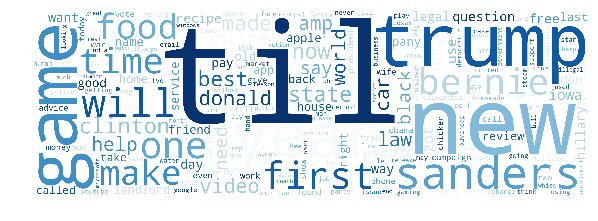

```python
c0_wc = wc.WordCloud(background_color='white', colormap='Blues',width=2700,
                     height=900).generate(df['titles'].str.cat(sep=' '))

plt.figure(figsize=(10,4))
plt.imshow(c0_wc)
plt.axis('off')
plt.show()
```

### 2.5 Vector Representation

After cleaning the titlts, the author transform the text data into its bag-of-words representation.

To be able to compute distances between texts, we need to first express text as multidimensional quantitative data as a bag of words. By treating frequency of each word as an attribute, we can create a sparse matrix of the entire corpus of text with which most attributes take on 0 values.

Computing the bag-of-words representation consists of the following steps:

1. Tokenization - splitting of words as they appear in the document
2. Vocabulary Building - creating a list of all words that appear in the entire corpus
3. Sparse Matrix Encoding - counting the frequency each word appears in the document

```python
# Determining the extreme occurences
vec = CountVectorizer(stop_words='english', ngram_range = (1,1)).fit(df['titles'])
bows = vec.transform(df['titles'])
total_words = bows.sum(axis=0)
word_count = [(word, total_words[0, idx]) for word, idx in  vec.vocabulary_.items()]
word_count =sorted(word_count, key = lambda x: x[1], reverse=True)
print('Upper extreme occurences:\n', word_count[0:10])
print()
print('Lower extreme occurences:\n',word_count[-10:-1])
```

```
Upper extreme occurences:
 [('til', 831), ('new', 292), ('trump', 252), ('sanders', 208), ('clinton', 194), ('year', 156), ('bernie', 146), ('2016', 143), ('donald', 127), ('hillary', 123)]

Lower extreme occurences:
 [('nearly000', 1), ('collaborate', 1), ('storyline', 1), ('ghibli', 1), ('indonesia', 1), ('populer', 1), ('terkenal', 1), ('haryanto', 1), ('pembalap', 1)]
```

```python
# Removing the extreme occurences
vectorizer = TfidfVectorizer(lowercase=True, stop_words = 'english', min_df=0.0008)
bows = vectorizer.fit_transform(df['titles'])
sample = bows.todense()
print('Length of Vocabulary: ', len(vectorizer.vocabulary_))
```

```
Length of Vocabulary:  1921
```

### 2.5 Number of Components

Using 1000 components, the author can explain 80% of the data.

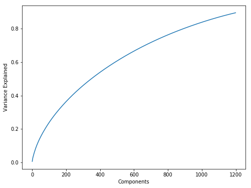

```python
lsa = TruncatedSVD(n_components = 1200)
X = lsa.fit_transform(bows)

plt.subplots(figsize = (8,6))
plt.plot(lsa.explained_variance_ratio_.cumsum());
plt.xlabel('Components');
plt.ylabel('Variance Explained');
```

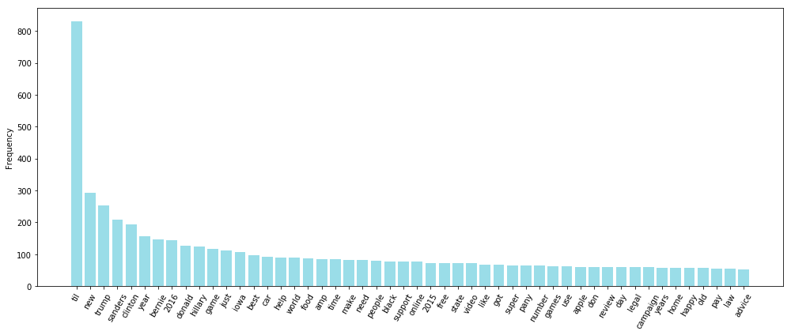

```python
top = word_count[:50]
top_n_words = []
top_n_counts = []
for i in range(len(top)):
    top_n_words.append(word_count[i][0])
    top_n_counts.append(word_count[i][1])

plt.figure(figsize=(14,6))
plt.bar(top_n_words, top_n_counts, color = "#9ADDE8")
plt.title('')
plt.ylabel('Frequency')
plt.xticks(rotation = 60)
plt.tight_layout()
```

## 3. KMeans Clustering Analysis

KMeans Clustering attempts to discover latent groupings of titles. KMeans clustering partitions n observations into k clusters in which each observation belongs to the cluster with the nearest mean, serving as a representative of the cluster. The clusters were evaluated by computing internal and external clustering validation measures and interpreting cluster membership.

```python
def intra_to_inter(X, y, dist, r):
    """Compute intracluster to intercluster distance ratio

    Parameters
    ----------
    X : array
        Data matrix with each row corresponding to a point
    y : array
        Class label of each point
    dist : callable
        Distance between two points. It should accept two arrays, each
        corresponding to the coordinates of each point
    r : integer
        Number of pairs to sample

    Returns
    -------
    ratio : float
        Intracluster to intercluster distance ratio
    """
    dist_P = []
    dist_Q = []
    for i, j in np.random.randint(low=0, high=len(y), size=[r,2]):
        # just skip the pair even if we end up having pairs less than r
        if i == j:
            continue
        # intracluster
        elif y[i] == y[j]:
            dist_P.append(dist(X[i], X[j]))
        # intercluster
        else:
            dist_Q.append(dist(X[i], X[j]))

    intra = np.sum(dist_P) / len(dist_P)
    inter = np.sum(dist_Q) / len(dist_Q)
    ratio = intra / inter
    return ratio
```

```python
def kmeans_cluster_search(X):
    """Implement KMeans on varying number of k clusters

    Parameters
    ----------
    X : DataFrame
        vector of features

    Returns
    -------
    inertias, iidrs, scs: lists
        lists of internal validation values
    """
    X = pd.DataFrame(X)
    fig, ax = plt.subplots(2, 5, dpi=150, sharex=True, sharey=True, figsize=(7,4),
                           subplot_kw=dict(aspect='equal'),
                           gridspec_kw=dict(wspace=0.01));
    inertias = []
    iidrs = []
    scs = []

    for i in range(2, 12):
        kmeans = KMeans(n_clusters=i, random_state=168) #168
        y = kmeans.fit_predict(X)
        inertias.append(kmeans.inertia_)
        iidrs.append(intra_to_inter(X.values, y, euclidean, 50))
        scs.append(silhouette_score(X, y))

        if i < 7:
            ax[0][i%7-2].scatter(X[0], X[1], s=12, c=y, alpha=0.5, marker='.');
            ax[0][i%7-2].set_title('$k=%d$'%i);
        else:
            ax[1][i%7].scatter(X[0], X[1], s=12, c=y, alpha=0.5, marker='.');
            ax[1][i%7].set_title('$k=%d$'%i);

    return inertias, iidrs, scs, ax
```

```python
X_ng_new = TSNE(random_state=1337).fit_transform(
    TruncatedSVD(n_components=1000).fit_transform(bows))
```

```python
def cluster_range(X, clusterer, k_start, k_stop, actual=None):
    """
    Return a dictionary of the cluster labels, internal validation
    values and, if actual labels is given, external validation values,
    for every number of clusters

    Parameters:
    -----------
    X: array
        Dataset
    clusterer: int
        Clusterer values of the KMeans
    k_start: int
        Starting number of clusters to be investigated
    k_stop: int
        Ending number of clusters to be investigated
    actual: array
        The external label used for validation

    Returns
    -------
    validation: dict
        Dictionary of the cluster labels, internal validation
        values and, if actual labels is given, external validation
        values, for every number of clusters
    """
    if actual is None:
        validation = {'ys':[],
                      'inertias': [],
                      'chs': [],
                      'iidrs': [],
                      'scs': []}

        for k in list(range(k_start, k_stop+1)):
            np.random.seed(11)
            kmeans_X = KMeans(n_clusters=k, random_state=clusterer.random_state)
            y_predict_X = kmeans_X.fit_predict(X)

            validation['ys'] += [y_predict_X]
            validation['inertias'] += [kmeans_X.inertia_]
            validation['chs'] += [calinski_harabaz_score(X, y_predict_X)]
            validation['iidrs'] += [intra_to_inter(X, y_predict_X,
                                                   euclidean, 50)]
            validation['scs'] += [silhouette_score(X,  y_predict_X)]

    else:
        validation = {'ys':[],
                      'inertias': [],
                      'chs': [],
                      'iidrs': [],
                      'scs': [],
                      'ps': [],
                      'amis': [],
                      'ars': []}

        for k in list(range(k_start, k_stop+1)):
            np.random.seed(11)
            X_new = TSNE(random_state=clusterer.random_state).fit_transform(X)
            kmeans_X = KMeans(n_clusters=k, random_state=clusterer.random_state)
            y_predict_X = kmeans_X.fit_predict(X)

            validation['ys'] += [y_predict_X]
            validation['inertias'] += [kmeans_X.inertia_]
            validation['chs'] += [calinski_harabaz_score(X_new, y_predict_X)]
            validation['iidrs'] += [intra_to_inter(X, y_predict_X,
                                                   euclidean, 50)]
            validation['scs'] += [silhouette_score(X,  y_predict_X)]

            validation['ps'] += [purity(actual, y_predict_X)]
            validation['amis'] += [adjusted_mutual_info_score(actual,
                                                              y_predict_X, average_method='max')]
            validation['ars'] += [ adjusted_rand_score(actual, y_predict_X)]

#         print(validation['iidrs'])

    return validation
```

```python
res = cluster_range(X, KMeans(random_state=1337), 2, 11)
```

```python
def plot_clusters(X, ys):
    """Plot clusters given the design matrix and cluster labels"""
    k_max = len(ys) + 1
    k_mid = k_max//2 + 2
    fig, ax = plt.subplots(2, k_max//2, dpi=150, sharex=True, sharey=True,
                           figsize=(7,4), subplot_kw=dict(aspect='equal'),
                           gridspec_kw=dict(wspace=0.01))
    for k,y in zip(range(2, k_max+1), ys):
        if k < k_mid:
            ax[0][k%k_mid-2].scatter(*zip(*X), c=y, s=1, alpha=0.8)
            ax[0][k%k_mid-2].set_title('$k=%d$'%k)
        else:
            ax[1][k%k_mid].scatter(*zip(*X), c=y, s=1, alpha=0.8)
            ax[1][k%k_mid].set_title('$k=%d$'%k)
    return ax
```

### 3.1 Visualization Valization of the Clusters

The Author explored different options and visualization echniques to group the different topics. Unfortunately, the author was not able to see any significant cluster that may satisfy rge following desired characteristics:

- Compact: points in the same cluster should be close together
- Separated: points not belonging in the cluster should be far from points in the cluster
- Balanced: the number of points in each cluster are comparable
- Parsimonious: the number of cluster should be as few as possible

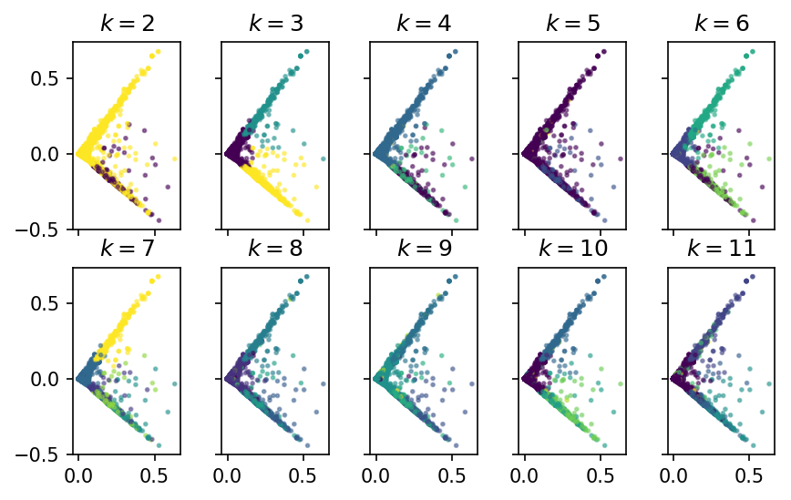

```python
inertias, iidrs, scs, ax = kmeans_cluster_search(X)
ax;
```

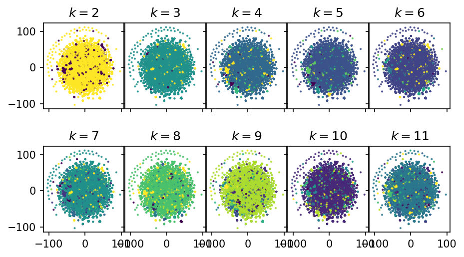

```python
plot_clusters(X_ng_new, res['ys']);
```

### 3.2 Internal Cluster Validation

In order to identify the optimal k parameter of the clusters, we use the following internal cluster validation metrics:

- **Sum of Squares Distances to centroids (SSE):** This metric indicates the distances of the individual data points from their respective cluster centroids. The smaller the distances suggest that the data points are more clumped.
- **Intracluster to intercluster distance ratio (IIDR):** This is the ratio between the average distance of two data points within the same cluster versus the average distance between two data points belonging to another cluster.
- **Calinski Harabaz Score (CH):** The score is defined as ratio between the within-cluster dispersion and the between-cluster dispersion
- **Silhouette coefficient (SCS):** Values range from -1 to 1 where 1 means there is good separation among clusters and -1 indicates some level of intersection between clusters.

In general, small values for SSE and IIDR and high values for CH and SCS are ideal for clustering quality.

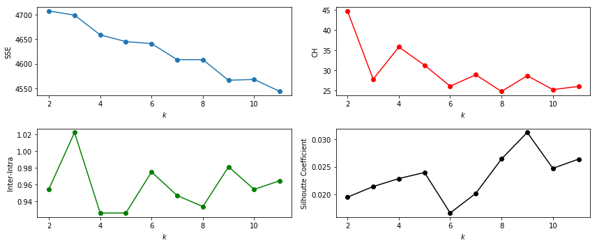

```python
fig, axes = plt.subplots(2, 2, figsize=(12, 5))
ks = np.arange(2, len(res['inertias'])+2)
axes[0][0].plot(ks, res['inertias'], '-o', label='SSE')
axes[0][0].set_xlabel('$k$')
axes[0][0].set_ylabel('SSE')

ks1 = np.arange(2, len(res['chs'])+2)
axes[0][1].plot(ks1, res['chs'], '-ro', label='CH')
axes[0][1].set_xlabel('$k$')
axes[0][1].set_ylabel('CH')

ks2 = np.arange(2, len(res['iidrs'])+2)
axes[1][0].plot(ks2, res['iidrs'], '-go', label='Inter-intra')
axes[1][0].set_xlabel('$k$')
axes[1][0].set_ylabel('Inter-Intra')

ks3 = np.arange(2, len(res['scs'])+2)
axes[1][1].plot(ks3, res['scs'], '-ko', label='Silhouette coefficient')
axes[1][1].set_xlabel('$k$')
axes[1][1].set_ylabel('Silhoutte Coefficient')

plt.tight_layout()
```

### 4. Interpreting the Clusters

Using k=4, the author clustered the titles into groups were they belong and displayed the top 10 words per cluster. As it turned out, these four clusters are as follow:

- Cluster A: Til cluster
- Cluster B: Trump Cluster
- Cluster C: Clinton Cluster
- Cluster D: Sanders Cluster

```python
def top_words(text, ngram = (1,1), n=None):
    """Returns most frequently occuring words

    Parameters
    ----------
    text : list, series, dataframe
        text data
    ngram : tuple
        ngram range
    n : integer
        number of top words to display

    Returns
    -------
    word_count: list
        list of top words sorted
    """
    vec = CountVectorizer(stop_words='english', lowercase=True, ngram_range = ngram, min_df = 0.0008, max_df=.052).fit(text)
    bows = vec.transform(text)
    total_words = bows.sum(axis=0)
    word_count = [(word, total_words[0, idx]) for word, idx in  vec.vocabulary_.items()]
    word_count =sorted(word_count, key = lambda x: x[1], reverse=True)
    return word_count[:n]
```

```python
k = 4

df['Cluster'] = KMeans(n_clusters=k, random_state = 1440).fit(X).labels_

cluster_list = {}
for i in range(k):
    cluster_list[i] = df[df['Cluster']==i]

top_df = pd.DataFrame()
for i in range(k):
    x = pd.Series(top_words(cluster_list[i]['titles'], ngram = (1,1), n=10),
                  name = 'Cluster_{} \n({}%)'.format(i,round((len(cluster_list[i])*100/len(df)),2)))
    top_df = top_df.append(x)

top_df.T
```

|  | Cluster_0 (1.48%) | Cluster_1 (91.13%) | Cluster_2 (3.47%) | Cluster_3 (3.92%) |
| --- | --- | --- | --- | --- |
| 0 | (free, 4) | (new, 269) | (supporters, 10) | (rubio, 12) |
| 1 | (legal, 4) | (year, 148) | (voters, 9) | (plan, 10) |
| 2 | (friend, 4) | (2016, 135) | (candidate, 9) | (students, 10) |
| 3 | (8969, 3) | (clinton, 123) | (super, 9) | (black, 10) |
| 4 | (1778, 3) | (game, 115) | (vote, 9) | (defeat, 9) |
| 5 | (til, 3) | (just, 98) | (tuesday, 8) | (inside, 9) |
| 6 | (dial, 3) | (best, 97) | (presidential, 8) | (clintons, 9) |
| 7 | (new, 3) | (car, 92) | (caucus, 8) | (gop, 8) |
| 8 | (carolina, 3) | (hillary, 89) | (final, 8) | (campaign, 8) |
| 9 | (ticket, 3) | (world, 89) | (2016, 7) | (john, 8) |

### 4.1 Til Cluster

This cluter is composed of the topics denoted by the phrase "today I learned" or 'til' composed of more than 90% of the total topic.

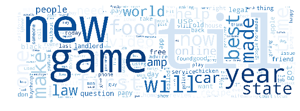

```python
c0_wc = wc.WordCloud(background_color='white', colormap='Blues',width=2700,
                     height=900
                    ).generate(cluster_list[1]['titles'].str.cat(sep=' '))
plt.figure(figsize=(10,6))
plt.imshow(c0_wc)
plt.axis('off')
plt.show()
```

### 4.2 Trump Cluster

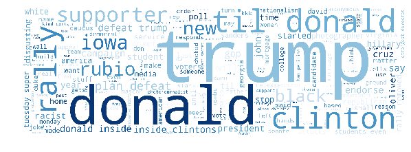

```python
c0_wc = wc.WordCloud(background_color='white', colormap='Blues',width=2700, height=900
                    ).generate(cluster_list[0]['titles'].str.cat(sep=' '))
plt.figure(figsize=(10,4))
plt.imshow(c0_wc)
plt.axis('off')
plt.show()
```

### 4.3 Hilary Cluster

This cluter is composed of the topics denoted by discussing anything related to Hilary Clinton composed of more than 3.92% of the total topic.

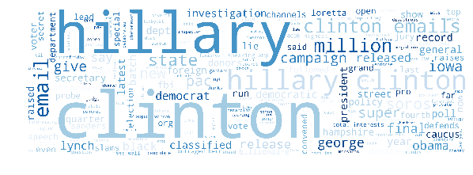

```python
c0_wc = wc.WordCloud(background_color='white', colormap='Blues',width=2700, height=900
                    ).generate(cluster_list[3]['titles'].str.cat(sep=' '))
plt.figure(figsize=(10,4))
plt.imshow(c0_wc)
plt.axis('off')
plt.show()
```

### 4.4 Sanders Cluster

This cluter is composed of the topics demoted by discussing anything related to Bernie Sander composed of more than 3.47% of the total topic.

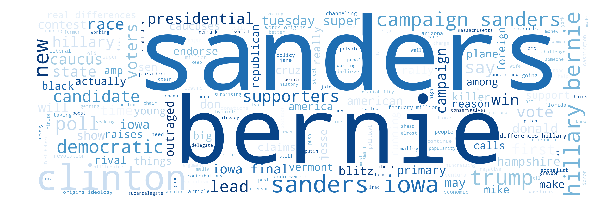

```python
c0_wc = wc.WordCloud(background_color='white', colormap='Blues',width=2700, height=900
                    ).generate(cluster_list[2]['titles'].str.cat(sep=' '))
plt.figure(figsize=(10,4))
plt.imshow(c0_wc)
plt.axis('off')
plt.show()
```

## 6. References and Acknowledgments

- Tristan Joshua Alba and Jon Colipapa(2018). Internet-based Sentiment Analysis for Trading: Collection and Preprocessing
- Christian Alis (2019). Lecture notes from Data Mining and Wrangling 2020
- General References: www.w3cschool.cn
- Learning Team Groupmates